# Rising to the threat: Reducing stereotype threat by reframing the threat as a challenge - ScienceDirect

## [Journal of Experimental Social Psychology](https://www.sciencedirect.com/journal/journal-of-experimental-social-psychology)

[Volume 46, Issue 1](https://www.sciencedirect.com/journal/journal-of-experimental-social-psychology/vol/46/issue/1), January 2010, Pages 166-171

# Report Rising to the threat: Reducing stereotype threat by reframing the threat as a challenge

https://doi.org/10.1016/j.jesp.2009.09.014[Get rights and content](https://s100.copyright.com/AppDispatchServlet?publisherName=ELS&contentID=S0022103109002510&orderBeanReset=true)

## Abstract

In two experiments, we found that the performance-inhibiting consequences of stereotype threat were eliminated when the threat was subtly reframed as a challenge. In Experiment 1, Black school children in North Carolina completed a 10-item mathematics test. Participants who reported their race before taking the test performed more poorly than participants who reported their race after completing the test, unless the test was framed as a challenge. Experiment 2 replicated this effect with undergraduates at a prestigious university. When reminded that they graduated from high schools that were poorly represented at the university, they performed more poorly than their peers on a math test. However, when the test was reframed as a challenge, this threat had no effect on their performance. These findings are discussed in terms of their theoretical and practical applications for both educational and athletic training.

## Keywords

Stereotype threat

Appraisal

Threat

Challenge

People perform more poorly across a broad range of evaluative domains when reminded that they belong to a group associated with weakness in that domain (for reviews, see Aronson and McGlone, 2009, Schmader et al., 2008, Shapiro and Neuberg, 2007, Steele et al., 2002). When reminded of their group membership, for example, White people struggle athletically (e.g., Stone, Lynch, Sjomeling, & Darley, 1999), Black people struggle academically (e.g., Steele & Aronson, 1995), women struggle mathematically (e.g., Shih et al., 1999, Spencer et al., 1999) and spatially (McGlone & Aronson, 2006), and men struggle linguistically (e.g., Keller, 2007). These so-called *stereotype threat* effects are pervasive, and research suggests that they explain in part why Black students continue to perform more poorly than White students in academic settings (e.g., Cohen et al., 2006, Walton and Spencer, 2009). The present research tested a simple theoretically-driven and domain-general intervention that was designed to eliminate stereotype threat effects.

## A summary of why stereotype threat impairs performance

Stereotype threat effects emerge for a variety of interrelated reasons, recently encapsulated in Schmader et al.’s (2008) three-mechanism stereotype threat model. They argued that stereotype threat activates physiological stress responses (e.g., Blascovich, Spencer, Quinn, & Steele, 2001), performance monitoring (e.g., Seibt & Förster, 2004), and the mental suppression of negative thoughts and emotions (e.g., Bosson, Haymovitz, & Pinel, 2004), all of which deplete limited cognitive resources. People experiencing stereotype threat consequently perform more poorly because they have fewer cognitive resources to devote to tasks than do their peers who are not experiencing threat.

Researchers have similarly identified a range of situational factors that moderate stereotype threat. As early studies showed, the threat disrupts performance only when the provoking stereotype is salient. Whereas Black students asked to report their race before taking a diagnostic academic test perform more poorly than their White counterparts, the effect does not occur if these students are asked to report their race after completing the test (e.g., Steele & Aronson, 1995). Participants must also identify with the target domain (e.g., Aronson, Lustina, Good, Keough, & Steele, 1999; Nosek, Banaji, & Greenwald, 2002), and the group with which they are associated (e.g., Schmader, 2002), as the negative stereotype is threatening only if it applies to a domain and a group that are personally relevant. Female engineers who work alongside male engineers are therefore particularly susceptible to stereotype threat, because their individual reputations and mathematical prowess are regularly challenged by the negative stereotype that women are mathematically less capable than men, an effect that has been shown in both laboratory and field experiments (e.g., Pronin, Steele, & Ross, 2004: Good, Aronson, & Harder, 2008). In sum, self-relevant threats impair performance by depleting valuable cognitive resources. Our research examines the hypothesis that such depletion might be prevented by conditions that encourage individuals to adopt a mindset that construes such threats as challenges.

## Challenge-framing as a threat-reduction mechanism

Over the past three decades, researchers have cast *threat* and *challenge* as opposing styles of appraising potentially stressful situations (e.g., Kobasa, 1982, Mendes et al., 2007). Challenges are cast positively, as situations in which people feel capable of conquering stressors, whereas threatening situations seem to demand more resources than the perceiver can muster (Blascovich et al., 1999, White, 2008).

Threat appraisal generates stress-related physiological responses and impairs performance in moderately difficult tasks (e.g., Blascovich et al., 1999). Challenge appraisal, conversely, facilitates performance by inducing adaptive stress responses and preparing the perceiver to address the stress (Scheepers, 2009, Vick et al., 2008). Importantly, people might interpret the same task as a challenge or a threat, depending on a range of situational factors, like the negative consequences of failure (e.g., Keller & Bless, 2008). Given the divergent consequences of threat and challenge appraisals for performance, reframing an otherwise threatening task as a challenge might reduce the effects of stereotype threat. Accordingly, we conducted two experiments to examine whether introducing typically threatening tasks as challenges might eliminate the damaging effects of stereotype threat on performance.

## Experiment 1: mitigating stereotype threat in elementary school students

In Experiment 1, we examined whether Black students might perform better on an otherwise threatening academic test if the test were framed as a challenge. Black students in North Carolina completed 10 sample items from a standardized math test called the End of Grade Exam (EOG), which is designed to ensure that children have attained a minimum standard of academic proficiency at the end of each grade. Some participants reported their racial background immediately before taking the math test, which made their racial group salient, whereas the remaining participants reported their racial background after completing the test. The experimenter framed the test either as a challenge or a threat by verbally describing it as a useful learning experience (challenge) or a true measure of their ability (threat). We expected students who reported their race before taking the test to perform more poorly than students who reported their race after completing the test, but only when the test was framed as a threat rather than a challenge.

### Methods

#### Participants

Fifty-one school children (age range: 9–13 years; *M =* 11.01 years, *SD* = .88; from grades 4 to 6) participated in this study, administered by a Latino male experimenter.<sup>1</sup> Data from two participants were lost due to a clerical error, leaving 49 participants in the remaining analyses. In both this and the following experiment, we refrained from asking participants to report their gender, since prior research has shown that males experience threat when asked to complete linguistic tasks (Keller, 2007), whereas females experience threat when asked to complete mathematical tasks (e.g., Shih et al., 1999). Asking for participants’ gender could have therefore introduced unintended sources of threat.

#### Materials, design, and procedure

Participants were randomly assigned to one of four conditions in a 2 (framing: threat vs. challenge) × 2 (race salience: high vs. low) between-participants design. Participants completed a 10-item EOG sample test in groups of four, though they sat behind small partitions that prevented them from seeing the other test-takers. Because participants within each group were randomly assigned to different conditions, the experimenter approached each participant individually and quietly explained the purpose of the test. Participants were therefore exposed to the instructions designed for their experimental condition, but not the instructions designed for the other conditions.

#### Framing manipulation

Participants in the *threat* and *challenge* conditions were given subtly different instructions, which emphasized either the diagnostic nature of the test (threat condition) or the role of the test in improving their general mathematical ability (challenge condition). Specifically, the experimenter told participants in the *threat* condition that the test would “show how good [they] were right now on this type of work,” and that “it would be able to measure [their] ability at solving math problems.” In contrast, those in the *challenge* condition were told that they “would learn a lot of new things,” and that “working on these problems might be a big help in school because it sharpens the mind and learning to do math well could help [them] in [their] studies” (adapted from Elliott & Dweck, 1988, who used the manipulation with similar samples). To ensure that participants encoded the manipulation, they were asked to describe the purpose of the test at the end of the experiment, and they were prompted to determine whether the goal of the study was to help them to learn (as in the challenge condition), or to measure their performance (as in the threat condition).

#### Race salience manipulation

Participants completed a demographic sheet in which they reported their race either before beginning or after finishing the test. Since reporting one’s race heightens the accessibility of potentially threatening stereotypes, participants in the high salience condition reported their race before beginning the test, whereas those in the low salience condition reported their race after completing the math test.

#### The EOG test

The North Carolina School Board administers the EOG at the end of each school year to measure whether students have reached an appropriate level of mathematical proficiency. The board creates different versions of the test for each grade, so participants completed a 10-item test consisting of items designed for students who had completed the previous grade (e.g., 5th graders completed the 4th grader test). Participants were given 10 min to complete the test. Participants did not perform differently by grade, *F*(2, 46) = 1.21, *p* = .31, $ηp2=.05$, so we collapsed scores across the school grade variable.<sup>2</sup>

### Results and discussion

#### Manipulation check

Of the 49 participants, six failed to describe the purpose of the test consistently with the framing condition to which they were randomly assigned. Excluding these participants did not change the pattern of results, so we included them in the remaining analyses.

#### Primary analyses

We began by conducting a 2 × 2 between-participants analysis of variance (ANOVA) to examine the effects of framing and race salience on test performance (proportion of correct answers relative to attempted questions). As expected, we found a significant 2-way interaction between the two independent variables, *F*(1, 45) = 4.34, *p* < .05, $ηp2=.09$ (see Fig. 1).

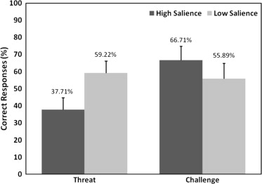

Fig. 1. Black school students’ performance on Mathematics End of Grade Exam in Experiment 1.

To examine this interaction further, we conducted simple effects analyses using the pooled error term. As expected, when race was salient, marginalized participants performed significantly better when the test was framed as a challenge rather than as a threat, *F*(1, 45) = 4.80, *p* < .04, $ηp2=.18$. When race was not made salient, however, framing did not influence marginalized participants’ test scores, *F <* 1.

Experiment 1 provided an encouraging first demonstration that thinking of threatening tasks as challenges can improve task performance; Black students performed significantly better in a stereotype threatening situation if they were prompted to reframe the threat as a challenge. We sought to replicate and extend this effect in Experiment 2, and to remedy several concerns with the design in Experiment 1.

Although we would have preferred to test a larger sample of students in Experiment 1, particularly students from other ethnic or racial backgrounds, we were unable to access a larger sample of school students. Accordingly, in Experiment 2 we turned to a population that allowed us to test a larger sample of participants. Specifically, instead of recruiting school students, we recruited undergraduates at Princeton University to complete a short mathematical test. We also manipulated threat and challenge using a subtle change in the title of the task, and used a novel instantiation of threat in which participants from high schools that were poorly-represented at Princeton were induced to think about their “minority” status before completing the test. Moreover, whereas we only tested Black participants in Experiment 1 who were susceptible to threat, we also tested participants from well-represented high schools who we did not expect to respond to the subtle framing manipulation.

## Experiment 2: mitigating stereotype threat in elite college students

### Pilot experiment

We began by exploring whether Princeton students who graduated from high schools that are poorly-represented at Princeton are indeed more threatened by the academic climate. Earlier research has shown that being in the numerical minority is sufficient to engender stereotype threat (Inzlicht et al., 2006, Inzlicht and Ben-Zeev, 2000). Nonetheless, to further explore the minority-representation-engenders-threat interpretation, we conducted a brief pilot experiment with our sample. Thirty-eight Princeton University undergraduates completed a brief pilot questionnaire. To mask the purpose of the questionnaire, participants were asked to answer a set of demographic questions (e.g., hometown and zip code). Within these filler questions, we included prompts to estimate the number of students from their high school who attend Princeton each year, and asked them to indicate how anxious they were when they began studying at Princeton. As expected, students who attended poorly-represented high schools tended to be more anxious than those who attended well-represented high schools, *r*(36) = .33, *p* = .04.

We also asked a separate sample of 19 Princeton undergraduates explicitly whether they believed that numerical representation on campus affected academic confidence, and why this might be. Participants were asked to indicate the students who tend to be most unsure about their academic ability at Princeton (1 = students from high schools with few students at Princeton; 4 = high school representation has no bearing on academic confidence; 7 = students from high schools with many students at Princeton), and to posit one or two explanations for why they believed this relationship exists.

Consistent with the results from the first sample, participants tended to believe that students from poorly-represented schools were more academically anxious at Princeton. Specifically, 16 of the 19 participants (84%) used the lower half of the scale, a far greater proportion than might be expected by chance, *χ*<sup>2</sup>(1, *N* = 19) = 8.90, *p* = .003, and their mean response was significantly lower than the scale’s midpoint of 4, *M =* 2.58, *SD* = .90, *t*(18) = −6.87, *p* < .10<sup>−6</sup>, $ηp2=.72$.

Three Princeton University undergraduate students who were blind to the purposes of the study coded the open-ended responses to determine why the pilot participants believed that students from poorly-represented schools would be more anxious at Princeton. The raters classified the responses into three categories, and found that 89% noted that students from poorly-represented high schools might experience a relative lack of support when they begin at Princeton, 37% believed that these students might feel more acutely like “little fish in a big pond,” and 11% noted that they would feel greater pressure to honorably represent their alma mater high school. These rationales are consistent with the suggestion that people experience threat when they experience a conspicuous lack of social support (e.g., Allen, Blascovich, & Mendes, 2002).

These pilot results suggest that Princeton undergraduates who graduated from poorly-represented high schools might experience academic threat when asked to report the name of their high school before taking an academic test. This novel instantiation of threat arguably differs from traditional instantiations like race and gender, which are outwardly visible, reified social categories. Nonetheless, it shares important features with race and gender stereotype threat: students in the minority group are expected to perform more poorly than the majority, and their academic success is therefore relatively precarious.<sup>3</sup>

### Main experiment

Having shown that Princeton undergraduates from poorly-represented high schools tend to be more academically anxious than those from highly-represented high schools, we sought to examine the performance implications of making this threatening identity salient and replicate the challenge-frame attenuation results obtained in Experiment 1.

### Methods

#### Materials, design, and procedure

Participants were randomly assigned to one of four conditions in a 2 (framing: threat vs. challenge) × 2 (school salience: high vs. low) between-participants design. Participants’ school representation (a continuous variable) was included as a third factor.

##### Threat vs. challenge framing

The experimenter approached participants individually, and asked whether they would be willing to complete a brief mathematical test. After agreeing to participate in the study, the experimenter gave participants one of two versions of a four-item mathematical test. The *threat* questionnaire was titled “Intellectual Ability Questionnaire,” and began by suggesting that participants consider the questionnaire as “reliable measure of [their] basic quantitative ability.” In contrast, the *challenge* questionnaire was titled “Intellectual Challenge Questionnaire,” and participants were told that it was a reliable measure of their quantitative ability, to “do as well as [they possibly could],” and to “treat the questionnaire as a challenge.” To ensure that participants processed the manipulation, the experimenter asked participants to recall the test’s purpose after completing the experiment.

##### School representation salience

The experimenter told participants that their scores would be stored anonymously so they could not be linked to their scores by name. Instead, participants provided information about their school, with the ostensible purpose of allowing us to catalogue their results. Specifically, participants wrote their school name, zip code, and the approximate number of students from their high school who attended Princeton each year. Participants either completed this demographic form before taking the test (*high salience* condition) or after completing the test (*low salience* condition).

##### Mathematical test

The mathematical test consisted of four items from a sample Graduate Record Examination quantitative section test. A sample of 10 pilot undergraduate students at Princeton completed 10 potential questions, from which we selected the four that ultimately constituted the test. We presented four questions because pilot participants spent about 75 s per question and we did not want the test to exceed 5 min in duration. To avoid ceiling and floor effects, we chose the four questions that were moderately difficult and, given the time constraint, did not require complex calculations.

### Results and discussion

#### Preliminary analyses

We began by examining whether participants who had attended poorly-represented schools also came from lower socioeconomic status (SES) backgrounds. To estimate SES, we collected the average annual household income within the zip code associated with each school (retrieved from http://www.listware.net/lookups/taxzip.asp). There was no relationship between the average income associated with each school’s zip code and the number of students it contributed to the incoming class at Princeton each year, *r* < .01, *p* = .98. This null correlation suggests that our instantiation of threat as high school representation was not merely a proxy for socioeconomic status.

Participants were also able to adequately recall the purpose of the test as stated in the test’s instructions. Specifically, participants in the threat condition verbally described the test as a measure of quantitative ability, whereas those in the challenge condition encoded the test as a challenge. In addition, 96% of a separate sample of 25 pilot participants agreed that the threatening description was indeed more threatening than the challenging description, and vice versa, and rated the threatening description as relatively more threatening on a 7-point scale anchored from 1 = challenging to 7 = threatening (*M<sub>threat</sub>* = 4.80, *SD =* 1.68 vs. *M<sub>challenge</sub>* = 2.88, *SD =* 1.17), *t*(23) = 5.63, *p* < .10<sup>−6</sup>, $ηp2=.57$. Respondents also reported fearing failure more strongly (on a scale from 1 = I would not fear failure at all to 7 = I would fear failure strongly) when taking a test framed using the threatening description (*M =* 4.11, *SD =* 2.01) rather than the challenging description (*M =* 3.19, *SD =* 1.35), *t*(35) = 2.23, *p* = .03, $ηp2=.12$.

#### Primary analyses

Since school representation is a continuous measure, we conducted hierarchical regression analyses to examine the pattern of results when we included school representation as a continuous measure.

We began by creating effect-coded contrasts on the framing (−1 challenge; +1 threat) and school salience (−1: low; +1 high) measures, and centering values on the school representation measure. We ran a two-step hierarchical regression analysis, regressing the three main effect contrasts and three two-way interactions on test performance at Step 1, and adding the three-way interaction at Step 2. The variables entered at Step 1 of the model did not significantly predict participants’ test performance, Δ*R<sup>2</sup>* = .06, *F*<sub>Δ</sub> = 1.26, *p* > .28. In contrast, the three-way interaction entered at Step 2 significantly predicted participants’ test scores beyond the six predictors entered at Step 1, *β* = .32, Δ*R<sup>2</sup>* = .06, *F*<sub>Δ</sub>(1, 115) = 8.11, *p* = .005 (see Fig. 2).

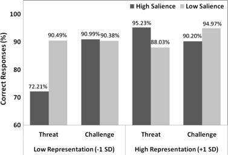

Fig. 2. Princeton undergraduate students’ performance on Mathematics Graduate Record Exam in Experiment 2. Low representation and high representation are calculated as 1 SD below and above the mean number of fellow high school students at Princeton, respectively.

We also conducted follow-up analyses to examine whether the effects of school representation and school salience differed depending on how the test was framed. We entered the centered school representation and school salience main effect variables at Step 1 and the interaction between centered school representation and school salience at Step 2, and examined their effects on test performance. The main effect variables did not significantly predict performance, Δ*R<sup>2</sup>* = .04, *F*<sub>Δ</sub>(2, 115) = 1.19, *p* = .31, but adding the interaction variable significantly enhanced the model’s predictive power, *β* = .75, Δ*R<sup>2</sup>* = .17, *F*<sub>Δ</sub>(1, 115) = 11.74, *p* < .001. As expected, participants from highly-represented schools outperformed those who came from poorly-represented schools, but only when school was made salient before participants took the test, *β* = .49, *t*(115) = 2.57, *p* = .01 vs. *β* = −.13, *t* < 1, respectively.

In contrast to these results in the threat conditions, the effects of school representation were eliminated completely when we framed the test as a challenge. In the same two-step hierarchical analysis, neither the centered attendance and school salience main effects at Step 1, nor the interaction of the two variables at Step 2, predicted participants’ test scores, Δ*R<sup>2</sup>* = .002, *F*<sub>Δ</sub> < 1, and Δ*R<sup>2</sup>* = .01, *F*<sub>Δ</sub> < 1, respectively. These findings suggest the potential benefits of helping students reframe threatening situations as challenges.

#### Summary

Experiment 2 replicated the results in Experiment 1, showing that the standard stereotype threat effect can be mitigated when an otherwise threatening task is framed as a challenge. We also used a novel instantiation of threat by showing that Princeton students who attended high schools that are rarely represented at Princeton can be induced to feel academic threat when their high school background is made salient. This novel form of threat is notable because it does not rely on strongly reified categories (e.g., race and gender), and appears to increase in potency as a function of under-representation; the more poorly a student’s high school is represented, the poorer their performance.

## General discussion

In two experiments, we found that reframing a threatening task as a challenge eradicated the negative effects of stereotype threat. This effect was apparent among Black school students in North Carolina (Experiment 1), and among Princeton University undergraduates from poorly-represented high schools (Experiment 2). In both cases, participants who were reminded that they belonged to a marginalized group performed more poorly than their peers on an academic test, except when the test was framed as a challenge. This manipulation was subtle and inexpensive, which suggests that it might be a useful stereotype threat-management intervention.

### Theoretical implications and practical applications

Previous studies have suggested the physiological benefits of framing stressors as challenges rather than threats (e.g., Scheepers, 2009, Vick et al., 2008). However, although those studies suggested that challenge-framing is more adaptive, they did not directly measure performance in stereotype-threatening contexts. The two experiments reported here extend these earlier findings by showing that people who otherwise perform more poorly because they experience a task as a threat perform as well as their peers when the task is reframed as a challenge.

One question that remains is whether challenge-framing merely weakens a threat, or whether it transforms the threat into a different experience altogether. Relevant earlier studies suggest that people tend to experience threats when they are concerned with preventing a negative outcome, whereas they tend to experience challenges when concerned with promoting a positive outcome (e.g., Keller, 2007). This relationship between threat and challenge appraisal, and prevention and promotion posturing, is consistent with Higgins’ Regulatory Focus Theory (RFT; e.g., 1998). Viewing stress appraisal through the lens of RFT suggests that threatening experiences impair performance because they engender avoidant behaviors, whereas challenging experiences promote an empowering approach orientation (see also Seibt & Forster, 2004). Thus, rather than merely dampening a threat, challenge-framing might recruit a motivational style that instantiates an adaptive stress-coping mechanism. Future research might test this question directly, but our findings offer preliminary evidence that challenge-framing prevents people from performing more poorly in the face of a threat.

The practical implications of these findings are far-reaching. Educators at all levels, from grade school to college, might ameliorate the effects of stereotype threat if they appropriately reframe threatening tests as challenges. Experiment 1 shows, for example, that academically marginalized school students performed just as well as their peers when just one extra sentence was added to the description of a mathematical test. Relative to these quite dramatic benefits, there is little cost in training teachers to describe stressful academic tests using more challenge-oriented terms. The same intervention might apply to other traditionally stressful performance domains—for example, athletes might perform better under pressure when the event is reframed as a challenge.

Of course different forms of challenge-framing might be effective in different situations. In practice, it may be difficult to convince people that their SATs, or a major athletic event, are challenging rather than threatening. One method of introducing a challenge frame might be to emphasize that people are capable of overcoming a disappointing performance, and the consequences of failure are less profound than they may seem. Consequently, competitors or test-takers might fixate less heavily on avoiding the threatening consequences of failure, instead focusing on the benefits of success.

## Acknowledgments

This research was conducted while the first author was at the Department of Psychology, Princeton University. We thank Margaret Gerbasi, Valerie Loehr, and Alison Newman for their invaluable assistance. Adam Alter gratefully acknowledges the financial support of the Woodrow Wilson Society of Scholars and a Charlotte Elizabeth Procter Fellowship, both at Princeton University, and Joshua Aronson acknowledges the support of National Science Foundation Grant #BCS-0621356 and a Spencer Foundation Grant.

## References

1. Allen et al., 2002

   K. Allen, J. Blascovich, W.B. Mendes

   Cardiovascular reactivity and the presence of pets and spouses: The truth about cats and dogs

   Psychosomatic Medicine, 64 (2002), pp. 727-739

   [View in Scopus](https://www.scopus.com/inward/record.url?eid=2-s2.0-0036740963&partnerID=10&rel=R3.0.0)Google Scholar
2. Aronson and McGlone, 2009

   J. Aronson, M. McGlone

   Stereotype and social identity threat

   T. Nelson (Ed.), The handbook of prejudice, stereotyping, and discrimination, Guilford, New York (2009)

   [Google Scholar](https://scholar.google.com/scholar_lookup?title=Stereotype%20and%20social%20identity%20threat&publication_year=2009&author=J.%20Aronson&author=M.%20McGlone)
3. Aronson et al., 1999

   J.A. Aronson, M.J. Lustina, C. Good, K. Keough, C.M. Steele

   White men can’t do math: Necessary and sufficient factors in stereotype threat

   Journal of Experimental Social Psychology, 35 (1999), pp. 29-46

   [View PDF](https://www.sciencedirect.com/science/article/pii/S0022103198913713/pdf?md5=5159076eb10a3d679d06ab4f8113e4fe&pid=1-s2.0-S0022103198913713-main.pdf)[View article](https://www.sciencedirect.com/science/article/pii/S0022103198913713)[View in Scopus](https://www.scopus.com/inward/record.url?eid=2-s2.0-0033480694&partnerID=10&rel=R3.0.0)Google Scholar

   J. Blascovich, S.J. Spencer, D. Quinn, C. Steele

   African Americans and high blood pressure: The role of stereotype threat

   Psychological Science, 12 (2001), pp. 225-229

   [CrossRef](https://doi.org/10.1111/1467-9280.00340)[View in Scopus](https://www.scopus.com/inward/record.url?eid=2-s2.0-0035345178&partnerID=10&rel=R3.0.0)Google Scholar

   J. Blascovich, W.B. Mendes, S.B. Hunter, K. Salomon

   Social “facilitation” as challenge and threat

   Journal of Personality and Social Psychology, 77 (1999), pp. 68-77

   [View in Scopus](https://www.scopus.com/inward/record.url?eid=2-s2.0-0033238061&partnerID=10&rel=R3.0.0)[Google Scholar](https://scholar.google.com/scholar_lookup?title=Social%20facilitation%20as%20challenge%20and%20threat&publication_year=1999&author=J.%20Blascovich&author=W.B.%20Mendes&author=S.B.%20Hunter&author=K.%20Salomon)
6. Bosson et al., 2004

   J.K. Bosson, E.L. Haymovitz, E.C. Pinel

   When saying and doing diverge: The effects of stereotype threat on self-reported versus non-verbal anxiety

   Journal of Experimental Social Psychology, 40 (2004), pp. 247-255

   [View PDF](https://www.sciencedirect.com/science/article/pii/S0022103103000994/pdfft?md5=1b9e705e36579a33e8911ebee5e4a223&pid=1-s2.0-S0022103103000994-main.pdf)[View article](https://www.sciencedirect.com/science/article/pii/S0022103103000994)[View in Scopus](https://www.scopus.com/inward/record.url?eid=2-s2.0-1542406354&partnerID=10&rel=R3.0.0)Google Scholar

   P.R. Clance

   The imposter phenomenon: Overcoming the fear that haunts your success

   Peachtree, Atlanta, GA (1985)

   [Google Scholar](https://scholar.google.com/scholar_lookup?title=The%20imposter%20phenomenon%3A%20Overcoming%20the%20fear%20that%20haunts%20your%20success&publication_year=1985&author=P.R.%20Clance)
8. Cohen et al., 2006

   G.L. Cohen, J. Garcia, N. Apfel, A. Master

   Reducing the racial achievement gap: A social–psychological intervention

   Science, 313 (2006), pp. 1307-1310

   [CrossRef](https://doi.org/10.1126/science.1128317)[View in Scopus](https://www.scopus.com/inward/record.url?eid=2-s2.0-33748297429&partnerID=10&rel=R3.0.0)Google Scholar

   E.S. Elliott, C.S. Dweck

   Goals: An approach to motivation and achievement

   Journal of Personality and Social Psychology, 54 (1988), pp. 5-12

   [View in Scopus](https://www.scopus.com/inward/record.url?eid=2-s2.0-0023779047&partnerID=10&rel=R3.0.0)[Google Scholar](https://scholar.google.com/scholar_lookup?title=Goals%3A%20An%20approach%20to%20motivation%20and%20achievement&publication_year=1988&author=E.S.%20Elliott&author=C.S.%20Dweck)
10. Good et al., 2008

    C. Good, J. Aronson, J. Harder

    Problems in the pipeline

    Journal of Applied Developmental Psychology, 29 (2008), pp. 17-28

    [View PDF](https://www.sciencedirect.com/science/article/pii/S0193397307001244/pdfft?md5=be4454e34f7e051b5a36c65a69a87e12&pid=1-s2.0-S0193397307001244-main.pdf)[View article](https://www.sciencedirect.com/science/article/pii/S0193397307001244)[View in Scopus](https://www.scopus.com/inward/record.url?eid=2-s2.0-41849151721&partnerID=10&rel=R3.0.0)[Google Scholar](https://scholar.google.com/scholar_lookup?title=Problems%20in%20the%20pipeline&publication_year=2008&author=C.%20Good&author=J.%20Aronson&author=J.%20Harder)
11. Higgins, 1998

    E.T. Higgins

    Promotion and prevention: Regulatory focus as a motivational principle

    M.P. Zanna (Ed.), *Advances in experimental social psychology*, Vol. 30, Academic Press, San Diego, CA (1998), pp. 1-46

    [View PDF](https://www.sciencedirect.com/science/article/pii/S0065260108603810/pdf?md5=027f0b8b98865fbb3a170c2be28b1ce1&pid=1-s2.0-S0065260108603810-main.pdf)[View article](https://www.sciencedirect.com/science/article/pii/S0065260108603810)[View in Scopus](https://www.scopus.com/inward/record.url?eid=2-s2.0-77956773952&partnerID=10&rel=R3.0.0)[Google Scholar](https://scholar.google.com/scholar_lookup?title=Promotion%20and%20prevention%3A%20Regulatory%20focus%20as%20a%20motivational%20principle&publication_year=1998&author=E.T.%20Higgins)

    M. Inzlicht, J. Aronson, C. Good, L. McKay

    A particular resiliency to threatening environments

    Journal of Experimental Social Psychology, 42 (2006), pp. 323-336

    [View PDF](https://www.sciencedirect.com/science/article/pii/S0022103105000739/pdfft?md5=d9dff40ced0c228840445def27ca4202&pid=1-s2.0-S0022103105000739-main.pdf)[View article](https://www.sciencedirect.com/science/article/pii/S0022103105000739)[View in Scopus](https://www.scopus.com/inward/record.url?eid=2-s2.0-33645949768&partnerID=10&rel=R3.0.0)[Google Scholar](https://scholar.google.com/scholar_lookup?title=A%20particular%20resiliency%20to%20threatening%20environments&publication_year=2006&author=M.%20Inzlicht&author=J.%20Aronson&author=C.%20Good&author=L.%20McKay)

    M. Inzlicht, T. Ben-Zeev

    A threatening intellectual environment: Why females are susceptible to experiencing problem-solving deficits in the presence of males

    Psychological Science, 11 (2000), pp. 365-371

    [CrossRef](https://doi.org/10.1111/1467-9280.00272)[View in Scopus](https://www.scopus.com/inward/record.url?eid=2-s2.0-0034279620&partnerID=10&rel=R3.0.0)Google Scholar

    J. Keller

    When negative stereotypic expectancies turn into challenge or threat: The moderating role of regulatory focus

    Swiss Journal of Psychology, 66 (2007), pp. 163-168

    [CrossRef](https://doi.org/10.1024/1421-0185.66.3.163)[View in Scopus](https://www.scopus.com/inward/record.url?eid=2-s2.0-34548388433&partnerID=10&rel=R3.0.0)Google Scholar

    J. Keller, H. Bless

    When positive and negative expectancies disrupt performance: Regulatory focus as a catalyst

    European Journal of Social Psychology, 38 (2008), pp. 187-212

    [CrossRef](https://doi.org/10.1002/ejsp.452)[View in Scopus](https://www.scopus.com/inward/record.url?eid=2-s2.0-41149118063&partnerID=10&rel=R3.0.0)Google Scholar

    S.C. Kobasa

    The hardy personality: Toward a social psychology of stress and health

    G.S. Sanders, J. Suls (Eds.), Social psychology of health and illness, Erlbaum, Hillsdale, NJ (1982), pp. 3-32

    [Google Scholar](https://scholar.google.com/scholar_lookup?title=The%20hardy%20personality%3A%20Toward%20a%20social%20psychology%20of%20stress%20and%20health&publication_year=1982&author=S.C.%20Kobasa)
17. McGlone and Aronson, 2006

    M. McGlone, J. Aronson

    Social identity salience and stereotype threat

    Journal of Applied Developmental Psychology, 27 (2006), pp. 486-493

    [View PDF](https://www.sciencedirect.com/science/article/pii/S0193397306000797/pdfft?md5=4f043ba4a852c352571820feb1ba1c36&pid=1-s2.0-S0193397306000797-main.pdf)[View article](https://www.sciencedirect.com/science/article/pii/S0193397306000797)[View in Scopus](https://www.scopus.com/inward/record.url?eid=2-s2.0-33750615108&partnerID=10&rel=R3.0.0)[Google Scholar](https://scholar.google.com/scholar_lookup?title=Social%20identity%20salience%20and%20stereotype%20threat&publication_year=2006&author=M.%20McGlone&author=J.%20Aronson)
18. Mendes et al., 2007

    W.B. Mendes, J. Blascovich, S.B. Hunter, B. Lickel, J.T. Jost

    Threatened by the unexpected: Physiological responses during social interactions with expectancy-violating partners

    Journal of Personality and Social Psychology, 92 (2007), pp. 698-716

    [CrossRef](https://doi.org/10.1037/0022-3514.92.4.698)[View in Scopus](https://www.scopus.com/inward/record.url?eid=2-s2.0-34249660598&partnerID=10&rel=R3.0.0)Google Scholar

    B.A. Nosek, M.R. Banaji, A.G. Greenwald

    Math = male, me = female, therefore math ≠ me

    Journal of Personality and Social Psychology, 84 (2002), pp. 44-59

    [View in Scopus](https://www.scopus.com/inward/record.url?eid=2-s2.0-1942506096&partnerID=10&rel=R3.0.0)[Google Scholar](https://scholar.google.com/scholar_lookup?title=Mathmale%2C%20mefemale%2C%20therefore%20mathme&publication_year=2002&author=B.A.%20Nosek&author=M.R.%20Banaji&author=A.G.%20Greenwald)
20. Pronin et al., 2004

    E. Pronin, C.M. Steele, L. Ross

    Identity bifurcation in response to stereotype threat: Women and mathematics

    Journal of Experimental Social Psychology, 40 (2004), pp. 152-168

    [View PDF](https://www.sciencedirect.com/science/article/pii/S002210310300088X/pdfft?md5=7e8efd0ad45f708e7b4292073c1eb930&pid=1-s2.0-S002210310300088X-main.pdf)[View article](https://www.sciencedirect.com/science/article/pii/S002210310300088X)[View in Scopus](https://www.scopus.com/inward/record.url?eid=2-s2.0-1542720909&partnerID=10&rel=R3.0.0)Google Scholar
21. Scheepers, 2009

    D. Scheepers

    Turning social identity threat into challenge: Status stability and cardiovascular reactivity during inter-group competition

    Journal of Experimental Social Psychology, 45 (2009), pp. 228-233

    [View PDF](https://www.sciencedirect.com/science/article/pii/S0022103108001996/pdfft?md5=c65cd35615ebef83e556b8c605c986d9&pid=1-s2.0-S0022103108001996-main.pdf)[View article](https://www.sciencedirect.com/science/article/pii/S0022103108001996)[View in Scopus](https://www.scopus.com/inward/record.url?eid=2-s2.0-56549121811&partnerID=10&rel=R3.0.0)Google Scholar

    T. Schmader

    Gender identification moderates stereotype threat effects on women’s math performance

    Journal of Experimental Social Psychology, 38 (2002), pp. 194-201

    [View PDF](https://www.sciencedirect.com/science/article/pii/S0022103101915008/pdf?md5=601c80a2c3af702a27788096d0b55e84&pid=1-s2.0-S0022103101915008-main.pdf)[View article](https://www.sciencedirect.com/science/article/pii/S0022103101915008)[View in Scopus](https://www.scopus.com/inward/record.url?eid=2-s2.0-0036122581&partnerID=10&rel=R3.0.0)[Google Scholar](https://scholar.google.com/scholar_lookup?title=Gender%20identification%20moderates%20stereotype%20threat%20effects%20on%20womens%20math%20performance&publication_year=2002&author=T.%20Schmader)

    T. Schmader, M. Johns, C. Forbes

    An integrated process model of stereotype threat effects on performance

    Psychological Review, 115 (2008), pp. 336-356

    [View in Scopus](https://www.scopus.com/inward/record.url?eid=2-s2.0-43449110716&partnerID=10&rel=R3.0.0)Google Scholar
24. Siebt and Förster, 2004

    B. Siebt, J. Förster

    Stereotype threat and performance: How self-stereotypes influence processing by inducing regulatory foci

    Journal of Personality and Social Psychology, 87 (2004), pp. 38-56

    Google Scholar
25. Shapiro and Neuberg, 2007

    J.R. Shapiro, S.L. Neuberg

    From stereotype threat to stereotype threats: Implications of a multi-threat framework for causes, moderators, mediators, consequences, and interventions

    Personality and Social Psychology Review, 11 (2007), pp. 107-130

    [CrossRef](https://doi.org/10.1177/1088868306294790)[View in Scopus](https://www.scopus.com/inward/record.url?eid=2-s2.0-38749119068&partnerID=10&rel=R3.0.0)Google Scholar

    M. Shih, T.L. Pittinsky, N. Ambady

    Stereotype susceptibility: Identity salience and shifts in quantitative performance

    Psychological Science, 10 (1999), pp. 80-83

    [CrossRef](https://doi.org/10.1111/1467-9280.00111)[View in Scopus](https://www.scopus.com/inward/record.url?eid=2-s2.0-0007129111&partnerID=10&rel=R3.0.0)Google Scholar

    S.J. Spencer, C.M. Steele, D.M. Quinn

    Stereotype threat and women’s math performance

    Journal of Experimental Social Psychology, 3 (1999), pp. 4-28

    [View PDF](https://www.sciencedirect.com/science/article/pii/S0022103198913737/pdf?md5=993c1933f91a94c43130f2f6f7863bcd&pid=1-s2.0-S0022103198913737-main.pdf)[View article](https://www.sciencedirect.com/science/article/pii/S0022103198913737)[View in Scopus](https://www.scopus.com/inward/record.url?eid=2-s2.0-0033477763&partnerID=10&rel=R3.0.0)[Google Scholar](https://scholar.google.com/scholar_lookup?title=Stereotype%20threat%20and%20womens%20math%20performance&publication_year=1999&author=S.J.%20Spencer&author=C.M.%20Steele&author=D.M.%20Quinn)

    C.M. Steele, J. Aronson

    Stereotype threat and the intellectual test performance of African–Americans

    Journal of Personality and Social Psychology, 69 (1995), pp. 797-811

    [View in Scopus](https://www.scopus.com/inward/record.url?eid=2-s2.0-0029411777&partnerID=10&rel=R3.0.0)[Google Scholar](https://scholar.google.com/scholar_lookup?title=Stereotype%20threat%20and%20the%20intellectual%20test%20performance%20of%20AfricanAmericans&publication_year=1995&author=C.M.%20Steele&author=J.%20Aronson)
29. Steele et al., 2002

    C.M. Steele, S. Spencer, J. Aronson

    Contending with group image: The psychology of stereotype and social identity threat

    M. Zanna (Ed.), Advances in experimental social psychology, Vol. 37, Academic Press (2002)

    Google Scholar
30. Stone et al., 1999

    J. Stone, C.I. Lynch, M. Sjomeling, J.M. Darley

    Stereotype threat effects on Black and White athletic performance

    Journal of Personality and Social Psychology, 77 (1999), pp. 1213-1227

    [View in Scopus](https://www.scopus.com/inward/record.url?eid=2-s2.0-0040960453&partnerID=10&rel=R3.0.0)Google Scholar
31. Vick et al., 2008

    S.B. Vick, M.D. Seery, J. Blascovich, M. Weisbuch

    The effect of gender stereotype activation on challenge and threat motivational states

    Journal of Experimental Social Psychology, 44 (2008), pp. 624-630

    [View PDF](https://www.sciencedirect.com/science/article/pii/S0022103107000352/pdfft?md5=936351254d047835d1b67a0cf02502a3&pid=1-s2.0-S0022103107000352-main.pdf)[View article](https://www.sciencedirect.com/science/article/pii/S0022103107000352)[View in Scopus](https://www.scopus.com/inward/record.url?eid=2-s2.0-41549119356&partnerID=10&rel=R3.0.0)Google Scholar

    G.M. Walton, S.J. Spencer

    Latent ability: Grades and test scores systematically underestimate the intellectual ability of negatively stereotyped students

    Psychological Science, 20 (2009), pp. 1132-1139

    [CrossRef](https://doi.org/10.1111/j.1467-9280.2009.02417.x)[View in Scopus](https://www.scopus.com/inward/record.url?eid=2-s2.0-69549088654&partnerID=10&rel=R3.0.0)Google Scholar

    J.B. White

    Fail or flourish? Cognitive appraisal moderates the effect of solo status on performance

    Personality and Social Psychology Bulletin, 34 (2008), pp. 1171-1184

    [CrossRef](https://doi.org/10.1177/0146167208318404)[View in Scopus](https://www.scopus.com/inward/record.url?eid=2-s2.0-49149103454&partnerID=10&rel=R3.0.0)[Google Scholar](https://scholar.google.com/scholar_lookup?title=Fail%20or%20flourish%20Cognitive%20appraisal%20moderates%20the%20effect%20of%20solo%20status%20on%20performance&publication_year=2008&author=J.B.%20White)

**<sup>1</sup>**

Approximately 30 students from one of several other ethnic backgrounds (predominantly White, Asian, and Latino) also completed the study, but there were fewer than 10 students from any of these other ethnic groups, so we were unable to examine reliably the effect of the manipulation on students from these other backgrounds. Participants were randomly assigned to a testing session, and were not separated based on ethnicity or gender.

**<sup>2</sup>**

Although we tested students in Grades 4, 5, and 6, they all took age-appropriate tests, which explains why older students did not perform better than younger students.

**<sup>3</sup>**

Two proximate mechanisms that might enhance the experience of threat for minority students are the *imposter phenomenon* and merely being associated with a minority of the population at large. Consistent with the imposter phenomenon (Clance, 1985), some students from poorly-represented high schools might have the sense that they do not belong at Princeton. The experience of merely being part of a salient minority might also heighten the experience of threat, independently of how members of the minority are expected to perform in the target domain, as minority group members reflect more strongly on their group than do majority group members.

Copyright © 2009 Elsevier Inc. All rights reserved.

[figure not shown]